# The Impact of Downsizing on Corporate Reputation

Converted from PDF `Zyglidopoulos-DownsizingCorporateReputation-2005-BJM.pdf` · 7 pages · anchors: page `#pN`, block `#pN-bK`

Page 1

## RESEARCH NOTE The Impact of Downsizing on Corporate

## Reputation

### Stelios C. Zyglidopoulos The Judge Institute of Management, University of Cambridge, Trumpington Street, Cambridge, CB2 1AG, UK

E-mail: szyglidopoulos@yahoo.com

This study investigates the impact that downsizing has on corporate reputation. Drawing on the relevant literatures, two hypotheses are developed and tested. The findings of the study are as follows. First, downsizing has a negative impact on corporate reputation. Second downsizing is more damaging to corporate reputation than ‘downscoping’–the sale of a division.

Downsizing, despite its increasing acceptance by corporations, has remained a controversial topic. Empirical evidence fail to support the notion that downsizing leads to superior financial performance in the long run (Baily, Bartelsman and Haltiwanger, 1994; Cascio, Young, and Morris, 1997; De Meuse, Bergmann and Vaderheiden, 1997). Some academics insist that downsizing, if done strategically, can benefit the firm (Burton, Keels and Shook, 1996), while others claim that downsizing as a strategy for improvement is ‘by and large, a failure’ (Cameron, 1996). Despite this lack of consistent evidence, however, managers have continued its practice (McKinley, Mone and Barker, 1998).

Within this context, the downsizing literature has investigated numerous issues, but has paid little attention to the impact of downsizing on corporate reputation. This paper, using data from Fortune’s ‘America’s Most Admired Corporations (AMAC) survey, addresses this issue by investigating how downsizing impacts corporate reputation, which is important for two reasons. First, a better understanding of the effect of downsizing on corporate reputation assists in the management of one of the most strategically important intangible firm resources, reputation (Barney, 1991; Dierickx and Cool, 1989; Fombrun, 1996; Roberts and Dowling, 1997). Second,

from a downsizing literature perspective, this study assists in better understanding the controversy surrounding downsizing.

### Downsizing and Corporate Reputation

Although the term ‘downsizing’ has often been used in the literature to encompass a number of related activities (Cameron, 1996; Cascio, Young and Morris, 1997), for the purposes of this study it refers exclusively to employment downsizing. There are two criteria used in the literature to classify a personnel reduction as downsizing. First, the reduction must be significant; Cascio, Young and Morris (1997) used a 5% reduction as a cut-offpoint. Second, this reduction must be intentional (Cameron, 1996), but given that significant workforce reductions are ‘less likely to be due to attrition’ (Littler and Innes, 2004), it is sufficient to say that a firm engaging in a significant workforce reduction is downsizing. But is an employee reduction resulting from the sale of a division downsizing? Here, ‘downsizing’ is used exclusively to refer to significant reductions in personnel as a result of layoffs (Burton, Keels and Shook, 1996; Worrell, Davidson and Sharma, 1991), whereas ‘downscoping’, which has been used to refer to strategic divestiture

British Journal of Management, Vol. 16, 253–259 (2005) DOI: 10.1111/j.1467-8551.2005.00460.x

r 2005 British Academy of Management

Page 2

programmes (Hoskinson and Hitt, 1991; Hoskinson, Johnson and Moesel, 1994), refers to significant reductions in personnel due to the sale of a division. In other words, while downsizing involves employees losing their jobs, downscoping involves employees keeping their jobs but working for different owners.

Corporate reputation, ‘the overall estimation in which a particular company is held by its various constituents’ (Fombrun, 1996, p. 37), is one of the most important intangible resources of a corporation. Research in strategic management suggests that a favourable reputation is an important source of sustainable competitive advantage (Dierickx and Cool, 1989; Fombrun and Shanley, 1990; Hall, 1992, 1993; Itami, 1987; McMillan and Maheshkumar, 1997). Fombrun (1996) argued that a solid reputation not only acts as a warranty in ambiguous situations, but also enables managers to charge higher prices for products and services. Moreover, Roberts and Dowling (1997) found that firms with better reputations find it easier to attain a competitive advantage.

In ‘linking’ the notion of downsizing with corporate reputation, two kinds of studies are identified within the downsizing literature. Indirect studies investigate the impact of downsizing on reputation through another aspect of the firm, while direct studies investigate the direct impact of downsizing on reputation.

Within indirect studies, different debates coexist. One is whether downsizing impacts financial performance. If downsizing has a positive impact on financial performance, given the positive relationship between financial performance and reputation (Roberts and Dowling, 1997; McMillan and Maheshkumar, 1997), then downsizing should have a positive impact on reputation as well. However, it is not clear that downsizing has a positive or negative impact on financial performance, as research findings are quite ambiguous. Numerous studies have failed to prove the existence of such a positive impact (Baily, Bartelsman and Haltiwanger, 1994; De Meuse, Bergmann and Vanderheiden, 1997), while Cascio, Young and Morris (1997, p. 1175) found that downsizing firms did not, in the long term, ‘show significantly higher returns than the average companies in their own industries’. Likewise, Lewin and Johnston (2000) reported that two surveys sponsored by the American Management Association (AMA) in 1994 and

1995 found little support that downsizing led to productivity improvements and profits. Therefore, downsizing has an indeterminate impact on financial performance, and consequently on corporate reputation.

Another indirect issue is ‘how’ investors perceive downsizing announcements. Studies examining the stock market’s reactions to downsizing announcements indicate that, in the short term, investors react negatively to downsizing decisions (Franz, Crawford and Dwyer, 1998; Lee, 1997). Worrell, Davidson and Sharma (1991, p. 667) tested the reaction of securities markets to 194 layoffannouncements and found that ‘a significantly negative stock market reaction is associated with layoffannouncements’. These findings indicate that since investors perceive downsizing as a negative development, they would probably downgrade their perception of a firm after a downsizing, given the link between stock market reactions and corporate reputation (Fombrun, 1996).

Moreover, the impact that downsizing has on intangible firm resources has received significant attention. Numerous authors suggest that innovation suffers during downsizing periods (Cascio, 1993; McKinley, 1992; McKinley, Mone and Barker, 1998). Amabile and Conti (1999, p. 630), after examining the work environment of a large high-technology firm before, during and after a major downsizing, found that ‘creativity and most creativity supporting aspects of the perceived work environment declined significantly during downsizing’. Fisher and White (2000) argued that from a social network perspective downsizing could damage a firm’s learning capacity much more than headcount ratios imply. For our purposes, the above findings indicate that downsizing negatively effects strategically important firm resources, which in turn negatively influence financial performance and therefore corporate reputation.

The second kind of research, investigating the direct impact of downsizing on reputation, is limited to two empirical studies. Using data from the AMAC survey, Karake (1998) found a negative relationship between downsizing and corporate reputation for social performance. This finding was supported by Zyglidopoulos (2004) who, using the same database, not only found that lay-offs have a negative impact on the firm’s reputation for social performance, but that high firm profitability, prior to lay-offs, intensified this impact – in other words, that ‘greater responsi-

254 S. C. Zyglidopoulos

Page 3

bilities are attributed to richer and stronger companies’ (Heugens and Schenk, 2004, p. 6).

Drawing on the above literatures and the resource-based view that perceives firms as bundles of unique and idiosyncratic resources and capabilities (Barney, 1991; Diericx and Cool, 1989; Rumelt, 1984; Wernerfelt, 1984), downsizing can be seen as having a negative impact on corporate reputation because it involves firms damaging their unique capabilities. Two arguments follow from this. If the various firm constituents see the connection between downsizing and loss of strategic capabilities, then firm reputation would suffer. Also, if downsizing leads to the destruction of valuable capabilities, this could account for the fact that no consistent evidence that downsizing improves the financial performance of the firm over the long term has been found (Cascio, Young and Morris, 1997; Lewin and Johnston, 2000) because any short-term gains are negated by longterm losses in capabilities. So, given the diminishing of the long-term prospects of the firm’s profitability, and the proven link between financial performance and corporate reputation (Deephouse and Carter, 2005), downsizing should lead to losses in reputation.

H1: Downsizing will be related to losses in corporate reputation.

Downsizing versus downscoping

There are indications in the literature that downsizing and downscoping have different impacts on reputation. Burton, Keels and Shook (1996) found that downsizing combined with refocusing and restructuring is beneficial to both healthy and declining firms. In addition, Markides (1992) found that downscoping firms tend to be refocusing because of over-diversification, which led them to poor performance, and that refocusing announcements were perceived positively by the markets. In other words, downscoping, seen as a corrective action to the firm’s over-diversification, is more likely to be seen in a positive light than downsizing.

There are more reasons, however, why downsizing and downscoping could have different effects on reputation. A firm engaged in downsizing violates a number of implicit psychological and social contracts existing between employees and management (Van Buren, 2000), which is not

the case during downscoping. Psychological contracts refer to ‘individual beliefs, shaped by the organization, regarding terms of an exchange agreement between individuals and their organization’ (Rousseau, 1995, p. 9: cited in Van Buren, 2000). ‘Social contracts’ refer to the normative ground rules through which society tries to regulate the fairness of implicit contractual agreements (Donaldson and Dunfee, 1994). Van Buren (2000) argues that during downsizing a firm violates both psychological and social contracts. In addition, one could argue that during downscoping, no implicit contracts are violated, but transferred from one owner to another, and moreover, the negative social impact that downsizing has on surrounding communities (Sloan and Underwood, 1996) does not take place. Therefore, downsizing would have a negative impact on the firm’s reputation, but not necessarily downscoping.

H2: Downsizing and downscoping will differ in their reputational impact.

### Methodology

Two sources of data were used: the AMAC survey and the Wall Street Journal Index (WSJI). The AMAC survey has been conducted by Fortune magazine yearly since 1983, in it, each corporation is rated relative to its competitors on eight attributes (quality of management, quality of products or services, innovativeness, ability to attract, develop and keep talented people, longterm investment value, financial soundness, use of corporate assets, and community and environmental responsibility). The respondents are senior executives and financial analysts from the ten largest companies in each of the 46 industries of the Fortune 1000 list. The AMAC survey has been criticized for having a significant financial halo (Brown, 1997; Fryxel and Wang, 1994), but, subsequent research has shown that if one controls for financial performance, it is a valid indicator of corporate reputation (Carter and Dukerich, 1998; Szwajkowski and Figlewicz, 1999). The second source of data, WSJI, is published yearly by the Wall Street Journal and provides summaries of all the news coverage related to a particular company for the year.

Data from the AMAC survey were used to identify the companies included in this study. Companies that appeared in the AMAC database

The Impact of Downsizing on Corporate Reputation 255

Page 4

for 1988 and 1991 were selected. The companies whose reputation scores were not available for these years or for the year prior (1987 and 1990, used as controls) were excluded. After this, 527 company x year data-points remained. Financial performance and employment count data were also drawn from the AMAC database.

Decreases in employees greater than 5% of the years before (1987, 1990) implied that the companies were downsizing, following Cascio, Young and Morris (1997) who, dealing with the same population of companies, found that a lower than 5% limit included companies whose employment declined through attrition, while a higher cut-off point unduly excluded larger corporations. This way, 145 instances of downsizing were identified. Further classification into pure downsizing companies and downscoping companies was not possible based on the AMAC data. For this reason, a graduate assistant under the author’s supervision went through the WSJI and identified the companies engaged in downsizing and downscoping. Companies identified from the AMAC database as having a greater than 5% decline in their workforce, but for whom the WSJI did not report any lay-offs or a division sale, were excluded from further analysis.

Independent variables. Downsizing was operationalized in three ways. First, downsizing was operationalized as any reduction in employee count. The criterion of ‘significant reduction’ was ignored, and the first attempt to ‘capture’ downsizing simply measured yearly percentage employment changes (DEMPL(t)). Second, in a more narrow sense, downsizing was operationalized by an indicator variable as any reduction in employee count greater than 5% (DOWN(t)). Third, the distinction between downsizing and downscoping was operationalized through the use of indicator variables (see Model 3). Two indicator variables were used to capture three possible states. One variable was used for firms engaged in downsizing, independent of whether they were downscoping during the same year (DN(t)), and another for instances where firms were engaged only in downscoping (DOWN- SCOP(t)). The third state was when a company engaged in neither of the above.

Dependent variables. The dependent variable was the overall reputational scores for the years

1988 and 1991 from the AMAC database. These yearly reputation scores were calculated through the consolidation of two populations surveyed by Fortune magazine yearly (financial analysts and industry executives) and eight dimensions of corporate reputation. Because Fortune measures reputation along eight dimensions, both Cronbach’s alpha and factor analyses were used to assure that there was an underlying and stable construct of reputation (Fombrun and Shanley, 1990). For the 1988 data, Cronbach’s alpha was 0.9727, and for the 1991 data a 5 0.9745. In addition, factor analysis showed that the eight attributes extracted a single factor with an eigenvalue of 6.831 and 6.972, which accounted for 85% and 87% of the variance, respectively. These results are supported by the findings of Fombrun and Shanley (1990), who found similar values for 1985 data. As for the measurement of reputation through questioning analysts and executives, Cronbach’s alphas of 0.925, and 0.9417 were calculated for 1988 and 1991, respectively. Therefore, the overall reputation of the firms can be treated as a single stable construct.

Control variables. Two control variables were used in this analysis: corporate financial performance (ROA(t)) and prior corporate reputation (CR(t-1)). Financial performance had to be controlled for because of its significant correlation with corporate reputation (Brown and Perry, 1995; McGuire, Schneeweis, and Banch, 1990). The ROA ratio drawn from the AMAC database was used (ROA(t)) as an indicator for financial performance because of its ‘stability and comparability across firms’ (Kim, Hwang, and Burgers, 1989). Prior levels of corporate reputation (CR(t-1)) were controlled for, for two reasons. First, because we are interested in the impact of events that took place during the years 1988 and 1991, their impact on the reputation scores of the firms can only be evaluated if we control for the reputation scores of the years prior. Second, as Fiol and Kovoor-Misra (1997) argued, prior levels of corporate reputation could impact the way stakeholders react to events.

The above variables were analysed using multivariate regressions. The data consisted of the combination of data-points from two time periods (1988, 1991) combined to increase the power of the results. No autocorrelation problems were expected because data from only two

256 S. C. Zyglidopoulos

Page 5

time periods were used rather than data from consecutive time periods, and by using the Durbin-Watson test, no such problems were found (Durbin Watson statistics remained very close to 2 for all models). Two stepwise and one forced-entry multivariate regression models were constructed. These models included control variables for prior corporate reputation and financial performance. In addition, each model tested for a different operationalization of downsizing, from simple changes in employment count (Model 1), to major negative changes in employment count (Model 2), to indicator variables indicating downscoping and downsizing (Models 3).

### Results

Table 1 presents the descriptive statistics and the correlations among the continuous variables used in this analysis. Because of the significant correlations between some independent and control variables, tests for multicolinearity were performed; the Variance Inflation Factors (VIF) were within acceptable limits (max 1.339).

Hypothesis 1 predicts that downsizing is positively correlated with losses in corporate reputation. As can be seen from all three models

in Table 2, this hypothesis is supported, no matter how broadly or narrowly downsizing is operationalized. In all three cases, the relevant variables reached adequate levels of significance and were included in the stepwise regression models (see Table 2). In Model 1, changes in employment (DEMPL(t)) were positively correlated with changes in corporate reputation scores ( 5 0.053, po0.01), indicating that drops in employment levels were linked to drops in corporate reputation scores. In Model 2, the indicator variable used for reductions in employee count greater than 5% (DOWN(t)) was negatively correlated with corporate reputations scores ( 5 0.68, po0.001), indicating that downsizing events were related to negative changes in corporate reputation scores. These findings were also supported by the significant changes of the F values after DEMPL(t) and DOWN(t) were added to the control variables, in Models 1 and 2, respectively. Moreover, in Model 3, there was a negative correlation between changes in all indicator variables and reputation scores–(DN(t)), indicating significant reductions in personnel through downsizing and/ or downscoping ( 5 0.085, po0.001), and downscoping exclusively (DOWNSCOP(t),

Table 1. Descriptives and pairwise correlations

Notes: CR(t) 5 Corporate Reputation Score at time (t); CR(t-1) 5 Corporate Reputation Score at time (t-1); ROA(t) 5 Return On Assets at time (t); DEMPL(t) 5 % Change in Employment from time (t-1) to time (t). *po0.05, two-tailed. **po0.01, two-tailed.

Table 2. Regression Analyses of Downsizing and Corporate Reputation–CR(t)

Variable Model 1 Changes in Employment

and Reputation Scores

Model 2 Downsizing and Reputation Scores

Model 3 Downsizing, Downscoping

and Reputation Scores

Std. Coefficient t Std. Coefficient t Std. Coefficient t

CR(t-1) 0.856 44.33*** 0.85 43.76*** 0.853 43.752*** ROA(t) 0.104 5.4*** 0.10 5.196*** 0.098 5.051*** DEMPL(t) 0.053 3.04** DOWN(t) 0.68 3.821*** DN(t) 0.085 4.857*** DOWNSCOP(t) 0.037 2.10* F 982.821*** 994.580*** 758.482*** Adjusted R<sup>2</sup> 0.849 0.85 0.864 Significance of F change 9.207** 14.598***

The Impact of Downsizing on Corporate Reputation 257

Page 6

5 2.10, po0.05). Therefore, one may conclude that employee decreases for any reason have a significant negative effect on reputation.

Hypothesis 2 predicts that downsizing (caused by lay-offs) and downscoping (caused by sales of divisions) have different effects on reputation. Evidence supporting this hypothesis can be found in Model 3, where the significance levels of the coefficients for downsizing and downscoping differed. Downsizing (DN(t)) reached higher levels of significance (po0.001) than downscoping (DOWNSCOP(t), po0.05) (see Table 2).

Although this evidence indicates that H2 is supported, further tests for the significance of the difference between the coefficients for downsizing and downscoping were conducted for Model 3. Following a procedure suggested in Neter, Wasserman, and Kunter (1990, p. 284), two regression models were compared, a full model (F) and a reduced one (R). The full model was Model 3, where different coefficients were assumed for downsizing (DV(t)) and downscoping (DOWNSCOP(t)), and a reduced model (R), where the two coefficients were assumed to be equal. The critical *F was 5.464F(0.95, 1, 470) ffi5.15, again supporting H2.

### Discussion, Implications and Conclusion

The purpose of this study was to investigate the impact of downsizing on corporate reputation. Through its findings it contributes not only to research dealing with the drivers of corporate reputation (Fombrun and Shanley, 1990; Rindova, 1997; Zyglidopoulos, 2001), but also the downsizing literature (Lewin and Johnston, 2000; McKinley, Mone and Barker, 1998) and the treatment of downsizing through a resourcebased view perspective.

First, it has found that while downsizing and downscoping have negative impacts on corporate reputation, downsizing is more damaging than downscoping. This suggests that managers and financial analysts (the population of our database) perceive downsizing to be a sign of weakness, despite oppositional arguments by some researchers. From a resource-based view, these findings indicate that beyond the damage that downsizing inflicts on other intangible firm resources (i.e. innovation and learning capacity) it also damages the firm’s reputation, which is

arguably its most strategically significant intangible resource.

In conclusion, this study found that downsizing has a negative impact on corporate reputation. Furthermore, downsizing has more of such a negative impact than downscoping. Therefore, adding to the indeterminate evidence on the effectiveness of downsizing, and the additional downsizing costs related to capability erosion and social responsibility, these findings suggest that downsizing has a higher potential for pain than gain.

### References

Amabile, T. M. and R. Conti (1999). ‘Changes in the work

environment for creativity during downsizing’, Academy of Management Journal, 42(6), pp. 630–641. Baily, M. N., E. J. Bartelsman and J. Haltiwanger (1994).

‘Downsizing and productivity growth: Myth or reality’. Working paper no. 4741, National Bureau of Economic Research. Barney, J. B. (1991). ‘Firm resources and sustained competitive

advantage’, Journal of Management, 17, pp. 99–120. Brown, B. (1997). ‘Stock market valuation of corporate

reputation for corporate social performance’, Corporate Reputation Review, 1, pp. 76–80. Brown, B. and S. Perry (1995). ‘Halo-Removed Residuals of

Fortune’s Responsibility to the Community and Environment - A Decade of Data’, Business and Society, 34(2), pp. 199–215. Burton, D. G., J. K. Keels and C. Shook (1996). ‘Downsizing

the firm: Answering the strategic questions’, Academy of Management Executive, 10(2), pp. 38–45. Cameron, K. (1996). ‘Downsizing’. In M. Warner (ed.),

International Encyclopedia of Business and Management, pp. 1051–1056. Routledge, London. Carter, S. and J. K. Dukerich (1998). ‘Corporate Responses to

Changes in Reputation’, Corporate Reputation Review, 1(3), pp. 250–270. Cascio, W. E. (1993). ‘Downsizing: What do we know? What

have we learned?’, Academy of Management Executive, 7(1), 95–104. Cascio, W. F., E.Young Clifford and R.Morris James (1997).

‘Financial Consequences of Employment-Change Decisions in Major U.S. Corporations’, Academy of Management Journal, 40(5), 1175–1189. De Meuse, K. P., T. L. Bergmann and P. A. Vanderheiden

(1997). ‘Corporate downsizing: Separating myth from fact’, Journal of Management Inquiry, 6, pp. 168–176. Deephouse, D. E. and S. M. Carter (2005). ‘An examination of differences between organizational legitimacy and organizational reputation’, Journal of Management Studies, 42(2), pp. 329–345. Dierickx, I. and K. Cool (1989). ‘Asset Stock Accumulation

and Sustainability of Competitive Advantage’, Management Science, 35(12), pp. 1504–1510. Donaldson, T. and T. W. Dunfee (1994). ‘Towards a Unified Conception of Business Ethics: Integrative Social

258 S. C. Zyglidopoulos

Page 7

Contracts Theory’, Academy of Management Review, 19, pp. 252–284. Fiol, C. M. and S. Kovoor-Misra (1997). ‘Two-way mirroring:

identity and reputation when things go wrong’, Corporate Reputation Review, 1 & 2, pp. 147–151. Fisher, S. R. and M. White (2000). ‘Downsizing in a learning

orgaization: Are there hidden costs?’, Academy of Management Review, 25(1), pp. 244–252. Fombrun, C. J. (1996). Reputation. Harvard Business School

Press, Boston MA. Fombrun, C. and M. Shanley (1990). ‘What’s in a Name?

Reputation Building and Corporate Strategy’, Academy of Management Journal, 33(2), pp. 233–258. Franz, D. R., D. Crawford and D. J. Dwyer (1998). ‘Down-

sizing, corporate performance, and shareholder wealth’, MidAmerican Journal of Business, 13(1), pp. 11–19. Fryxell, G. E. and J. Wang (1994). ‘The Fortune Corporate

‘Reputation’ Index: Reputation for What?’, Journal of Management, 20(1), pp. 1–14. Hall, R. (1992). ‘The strategic analysis of intangible resources’,

Strategic Management Journal, 13, pp. 135–144. Hall, R. (1993). ‘A Framework Linking Intangible Resources

and Capabilities to Sustainable Competitive Advantage’, Strategic Management Journal, 14, pp. 607–618. Heugens, Pursey P. M. A. R and Hans Schenk (2004). ‘The

public affairs of corporate restructuring’, Journal of Public Affairs, 4(1), 6–9. Hoskisson, R. E. and M. A. Hitt (1991). Downscoping: How to

tame the diversified firm. New York, Oxford University Press. Hoskisson, R. E., R. A. Johnson and D. M. Douglas (1994).

‘Corporate Divestiture Intensity in Restructuring Firms: Effects of Governance, Strategy, and Performance’, Academy of Management Journal, 37(5), pp. 1207–1251. Itami, H. (1987). Mobilizing Invisible Assets. Harvard Uni-

versity Press, Cambridge, MA. Karake, Z. A. (1998). ‘An examination of the impact of

organizational downsizing and discrimination activities on corporate social responsibility as measured by a company’s reputation index’, Management Decision, 36(3), pp. 206–216. Kim, W., P. Hwang and W. Burgers (1989). ‘Global Diversi-

fication Strategy and Corporate Profit Performance’, Strategic Management Journal, 10(1), pp. 45–57. Lee, P. M. (1997). ‘A comparative analysis of layoffannounce-

ments and stock price reactions in the United States and Japan’, Strategic Management Journal, 18, pp. 879–894. Lewin, J. E. and W. J. Johnston (2000). ‘The impact of

downsizing and restructuring on organizational competitiveness’, Competitiveness Review, 10(1), pp. 45–55. Littler, C. R. and P. Innes (2004). ‘The Paradox of Managerial

Downsizing’, Organization Studies, 25(7), pp. 1159–1184.

Markides, C. C. (1992). ‘Consequences of corporate refocusing:

ex ante evidence’, Academy of Management Journal, 35(2), pp. 398–412. McGuire, J. B., T. Schneeweis and B. Banch (1990). ‘Percep-

tions of Firm Quality: A Cause or Result of Firm Performance’, Journal of Management, 16(1), pp. 167–180. McKinley, W. (1992). ‘Decreasing organizational size: To un-

tangle or not to untangle?’, Academy of Management Review, 17, 112–123. McKinley, W., M. A. Mone and V. L. Barker III (1998). ‘Some

ideological foundations of organizational downsizing’, Journal of Management Inquiry, 7(3), pp. 198–212. McMillan, S. G. and P. J. Maheshkumar (1997). ‘Sustainable

Competitive Advantage and Firm Performance: The Role of Intangible Resources’, Corporate Reputation Review, 1, pp. 81–85. Neter, J., W. Wasserman and M. Kutner (1990). Applied Linear

Statistical Models. Irwin, Homewood, IL. Rindova, V. (1997). ‘The Image Cascade and the Formation of

Corporate Reputations’, Corporate Reputation Review, 1, 189–194. Roberts, P. E. and G. R. Dowling (1997). ‘The Value of a

Firm’s Corporate Reputation: How Reputation Helps Attain and Sustain Superior Performance’, Corporate Reputation Review, 1 & 2, pp. 72–76. Rousseau, D. M. (1995). Psychological Contracts in Organiza-

tions: Understanding Writen and Unwritten Agreements. Sage, Thousand Oaks CA. Rumelt, R. P. (1984). ‘Towards a strategic theory of the firm’.

In R. Lamb (ed.), Competitive Strategic Management, pp. 556–570. Prentice-Hall, Englewood Cliffs, NJ. Sloan, A. and A. Underwood (1996). ‘The hit men’, Newsweek,

127(9), pp. 44–49. Szwajkowski, E. and R. E. Figlewicz (1999). ‘Evaluating

corporate performance: A comparison of The Fortune Reputation Survey and The Socrates Social Ranking Database’, Journal of Managerial Issues, XI(2), pp. 137–154. Van Buren III, H. J. (2000). ‘The bindingness of social and psy-

chological contracts: towards a theory of social responsibility in downsizing’, Journal of Business Ethics, 25, pp. 205–219. Wernerfelt, B. (1984). ‘A Resource-based View of the Firm’,

Strategic Management Review, 5, pp. 171–180. Worrell, D. L., W. N. Davidson and V. M. Sharma (1991).

‘Layoffannouncements and stockholder wealth’, Academy of Management Journal, 34, pp. 662–678. Zyglidopoulos, C. S. (2001). ‘The Reputational Impact of

Accidents’, Business and Society, 40(4), pp. 416–441. Zyglidopoulos, C. S. (2004). ‘The Impact of Downsizing on the

Corporate Reputation for Social Performance’, Journal of Public Affairs, 4(1), pp. 11–25.

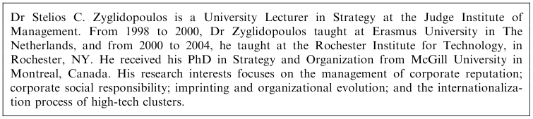

**text found inside the figure**

Dr Stelios C. Zyglidopoulos is a University Lecturer in Strategy at the Judge Institute of Management. From 1998 to 2000, Dr Zyglidopoulos taught at Erasmus University in The Netherlands, and from 2000 to 2004, he taught at the Rochester Institute for Technology, in Rochester, NY. He received his PhD in Strategy and Organization from McGill University in Montreal, Canada. His research interests focuses on the management of corporate reputation; corporate social responsibility; imprinting and organizational evolution; and the internationalization process of high-tech clusters.

The Impact of Downsizing on Corporate Reputation 259